# STAT 340 Midterm exam

## Question 1 (MC/R use)

### a) [6 pts] Derangement problem

You are a professor at a prestigious university. One day, just after you finish grading your students’ midterms, you accidentally spill coffee all over the entire pile of exams. By coincidence, the coffee ONLY destroys the name on each exam, so that you cannot read which student submitted which exam. The next day, you bring the exams to class and randomly distribute the exams back to your students, so that each student receives an exam back completely at random.

What is the probability, as a function of the number of students $N$, that **every student gets a different exam**? (i.e. not a SINGLE student gets their own exam back).

Write a function `mc.derange(n,i)` that accepts 2 arguments:

- `n` is the number of students in your class
- `i` is the number of Monte Carlo iterations used (defaults to 1000)
  - *hint:* recall that to set a default argument, use `i=1000` in the function statement (this has actually already been done for you below)

and returns an output between 0 and 1 showing the proportion of iterations where every student gets a different exam.

(Hint: you can use `sample()` to permute a vector, `!=` to check if two vectors are different in each element, and `all()` to check if all elements in a vector are `TRUE`)

```r
# dependent
mc.derange = function(n,i=1000){
  nomat=0
  students= c(1:n)

  results = rep(NA,i)
  for(j in 1:i){
    exams= sample(c(1:n))
    compare= (exams==students)
    if (all(compare==FALSE)){
      nomat= nomat + 1
    }
  }
  return(nomat/i)
}

# if you did it right, this result should be between 0.32 and 0.42
mc.derange(20,1000)
```

```
## [1] 0.339
```

### b) [4 pts] Visualize results

It can be shown that the theoretically correct probability is exactly equal to $\operatorname{floor}(n!/e-\frac12)/n!$ which rapidly converges $\to1/e\approx0.367879$ as $n\to\infty$ (after $n>9$, the error between the exact value and $1/e$ is less than $10^{-7}$)

The chunk below (already done for you), runs your `mc.derange` function for $n=2,3,...,9$ and saves the results in a data frame named `df.derange`. Use this data frame to produce a visualization comparing the theoretical values with your Monte Carlo computed values (plot both with respect to `n`).

(You can use either `ggplot` functions or base R functions, but try to plot both on the same plot if possible). Make sure to have appropriate title and axes labels! (default or bad titles/labels may be penalized!)

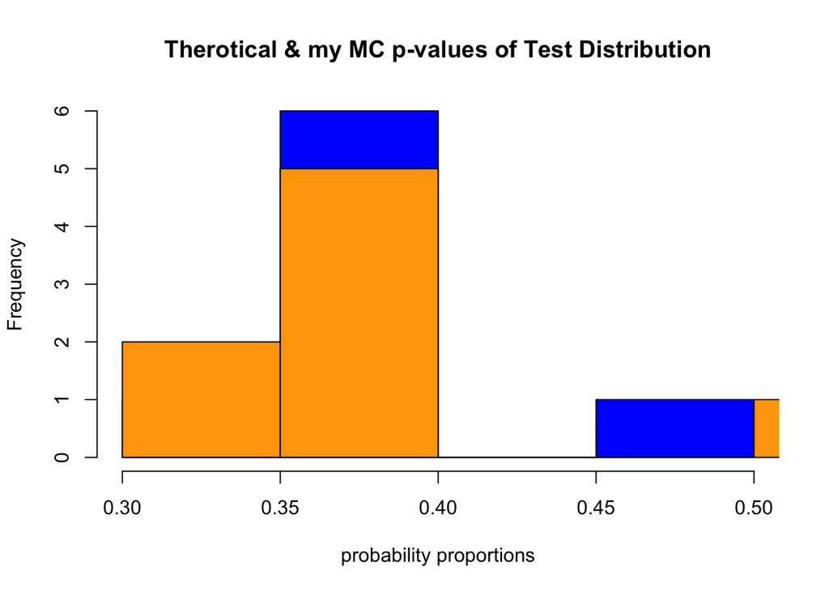

```r
df.derange = tibble(
  n = 2:9,
  theory = c(0.5, 0.333333, 0.375, 0.366667, 0.368056, 0.367857, 0.367882, 0.367879),
  mc = sapply(2:9,mc.derange)
)

hist(df.derange$theory, col="blue", main="Therotical & my MC p-values of Test Distribution", xlab="probability proportions")
hist(df.derange$mc, col="orange", add=TRUE)
```

## Question 2 (Testing/Estimation)

### a) [10 pts] Testing widgets

You are an analyst for the USDW (US Department of Widgets); your job is to make sure widget factories are operating in accordance with very strict federal widget guidelines. Each year, widget companies are required to submit a sample of widgets for inspection to make sure they are safe and effective. Each year, you also choose a small subset of widget companies to audit to make sure they are not engaging in deceptive business practices by fraudulently manipulating their samples.

This year, you chose to audit UW-Madison (United Widgeteers of Madison). You go undercover and secretly collect a high quality representative sample (`samp1` below) of widgets from a UW-Madison factory to compare with the sample they provided for inspection (`samp2` below).

```r
samp1 = c(5.672, 6.023, 7.143, 11.887, 5.976, 7.309, 5.679, 7.286, 10.209, 5.718,
          6.901, 5.431, 7.112, 9.206, 9.327, 11.013, 8.663, 8.973, 6.456, 12.901,
          6.441, 5.658, 5.562, 13.885, 10.175, 11.052, 9.356, 11.507, 6.148, 5.717,
          5.063, 6.191, 6.243, 6.185, 7.691, 6.784, 7.393, 9.566, 5.991, 6.159,
          8.79, 6.781, 18.458, 6.613, 10.373, 8.365, 7.811, 8.17, 7.608, 5.179,
          7.396, 6.033, 6.247, 9.427, 6.952, 13.344, 10.973, 5.038, 6.851, 5.204,
          5.44, 8.29, 6.652, 7.967, 5.379, 8.58, 7.439, 6.886, 8.61, 6.957, 5.777,
          14.26, 8.015, 7.618, 5.429, 6.487, 5.725, 6.147, 9.373, 6.436, 8.004,
          7.81, 6.771, 6.292, 5.509, 6.099, 11.195, 6.147, 5.835, 17.068, 6.047,
          5.433, 10.893, 5.738, 6.306, 6.385, 8.558, 7.8, 6.103, 10.797)

samp2 = c(10.056, 9.653, 9.517, 10.923, 9.966, 6.291, 6.34, 3.982, 6.303, 6.07,
          7.678, 8.672, 5.488, 8.511, 9.386, 8.897, 7.606, 6.848, 6.822, 8.762,
          6.569, 8.568, 9.013, 9.615, 8.649, 6.712, 8.895, 6.939, 5.351, 3.818,
          5.068, 10.701, 7.629, 7.803, 7.218, 5.476, 5.029, 9.102, 11.569, 8.379,
          10.972, 11.684, 9.192, 8.924, 7.634, 9.118, 3.333, 10.061, 7.848, 8.284,
          8.168, 7.703, 9.906, 7.568, 10.972, 7.429, 6.54, 8.537, 3.369, 8.549,
          10.094, 5.865, 6.583, 6.752, 5.556, 5.299, 8.118, 9.128, 7.524, 6.934,
          9.12, 10.226, 8.579, 8.64, 8.707, 7.248, 5.582, 10.05, 8.506, 10.384,
          9.603, 7.529, 5.795, 8.43, 8.273, 10.792, 9.792, 7.787, 11.407, 7.845,
          9.575, 9.122, 10.057, 8.716, 6.58, 7.375, 8.196, 6.673, 11.114, 6.846)
```

Carefully inspect the two samples and conduct a test at $\alpha=0.05$ to decide if UW-Madison falsified the sample they provided for inspection (i.e. did the two samples come from the same distribution?). Report a p-value and write a clear conclusion.

(Hint: First, plot histograms of the two samples. Do they look similar? Then, look at a few different summary statistics. What do you notice? If they seem different, can you find a statistic helps you differentiate them? Remember, if two samples come from the *exact* same distribution, you should expect them to have similar statistical properties.)

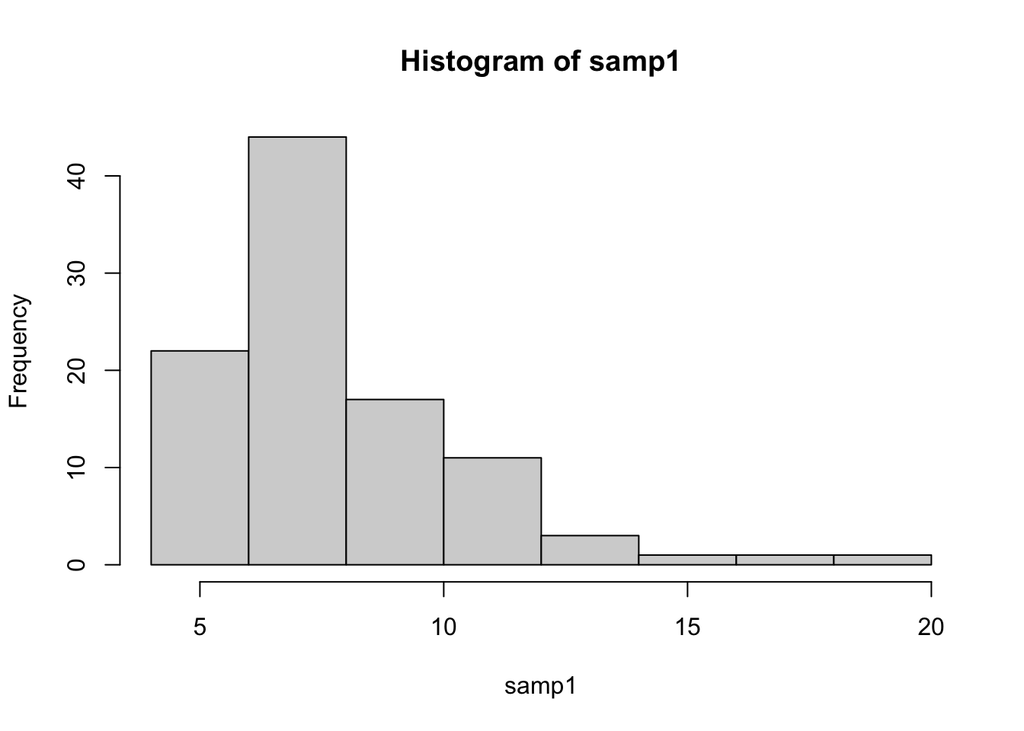

```r
# permutation
hist(samp1)
```

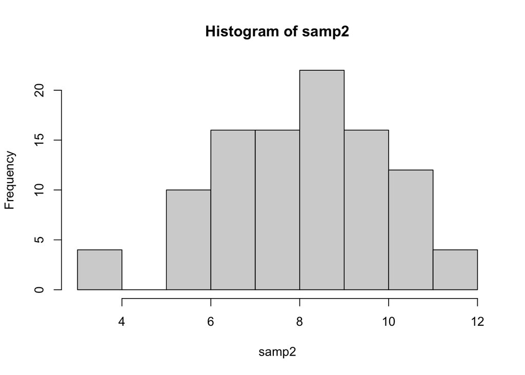

```r
hist(samp2)
```

```r
bothsamps = c(samp1,samp2)
N = 10000
results = rep(NA,N)
for(i in 1:N){
  x = split(sample(bothsamps), rep(1:2, c(100,100)))
  results[i] = mean(x[[2]]) - mean(x[[1]])
}

mean(results)
```

```
## [1] -0.002317752
```

### b) [10 pts] Confidence interval

Approximate the true distribution of widgets as a normal distribution with a known variance of 6 and unknown mean. Using your own sample (`samp1`), construct a 95% confidence interval for the true mean of widgets from this factory.

```r
qnorm( c(0.025, 0.975), mean=mean(samp1), sd=sqrt(6))
```

```
## [1]  2.994308 12.596132
```